# COMP47590 Advanced Machine Learning

# Basic Machine Learning in Python - MNIST

## Imports

To build predictive models in Python we use a set of libraries that are imported here. In particular **pandas** and **sklearn** are particularly important.

```python
#import os
#import subprocess
import io
import random

import sys
!{sys.executable} -m pip install joblib==1.1.0
!{sys.executable} -m pip install pandas-profiling[notebook]
!{sys.executable} -m pip install scikit-learn==1.0.2
```

[output not shown]

```python
import pandas as pd # core data handling package
import numpy as np # core data handling package
import matplotlib # core plotting functioanlity
import matplotlib.pyplot as plt
%matplotlib inline

import seaborn as sns # nicer plotting functionlity
#import pandas_profiling # Nice exploratory data analysis package
import missingno # For nice missing number analysis

import sklearn # For basic machine learning functionality
import sklearn.preprocessing
import sklearn.metrics
import sklearn.model_selection
import sklearn.tree
import sklearn.ensemble
import sklearn.svm
import sklearn.linear_model
import sklearn.neighbors
import sklearn.neural_network
```

## Data Prep

### Setup

Take only a sample of the dataset for fast testing

```python
data_sampling_rate = 0.1
```

Setup the number of folds for all grid searches (should be 5 - 10)

```python
cv_folds = 2
```

Set up a dictionary to store simple model performance comparions

```python
model_valid_accuracy_comparisons = dict()
model_accuracy_comparisons = dict()
model_tuned_params_list = dict()
```

### Load Data

Load the dataset and explore it.

```python
file_name = 'fashion-mnist_train.csv'

target_feature = "label"
num_classes = 10
classes = {
    0: "T-shirt/top", 1: "Trouser", 2: "Pullover", 3: "Dress",
    4: "Coat", 5: "Sandal", 6: "Shirt", 7: "Sneaker", 8: "Bag", 9: "Ankle boot"}
```

```python
dataset = pd.read_csv(file_name)
dataset = dataset.sample(frac=data_sampling_rate) #take a sample from the dataset so everyhting runs smoothly
display(dataset.head())
display(dataset.tail())
```

|  | label | pixel1 | pixel2 | pixel3 | pixel4 | pixel5 | pixel6 | pixel7 | pixel8 | pixel9 | ... | pixel775 | pixel776 | pixel777 | pixel778 | pixel779 | pixel780 | pixel781 | pixel782 | pixel783 | pixel784 |
| --- | --- | --- | --- | --- | --- | --- | --- | --- | --- | --- | --- | --- | --- | --- | --- | --- | --- | --- | --- | --- | --- |
| 1189 | 8 | 0 | 0 | 0 | 0 | 0 | 0 | 0 | 0 | 1 | ... | 164.0 | 171.0 | 161.0 | 146.0 | 102.0 | 0.0 | 0.0 | 0.0 | 0.0 | 0.0 |
| 1062 | 3 | 0 | 0 | 0 | 0 | 0 | 0 | 1 | 0 | 7 | ... | 0.0 | 0.0 | 0.0 | 0.0 | 0.0 | 0.0 | 0.0 | 0.0 | 0.0 | 0.0 |
| 631 | 7 | 0 | 0 | 0 | 0 | 0 | 0 | 0 | 0 | 0 | ... | 0.0 | 0.0 | 0.0 | 0.0 | 0.0 | 0.0 | 0.0 | 0.0 | 0.0 | 0.0 |
| 1396 | 2 | 0 | 0 | 0 | 0 | 0 | 0 | 0 | 0 | 0 | ... | 1.0 | 1.0 | 0.0 | 0.0 | 68.0 | 108.0 | 64.0 | 0.0 | 0.0 | 0.0 |
| 401 | 6 | 0 | 0 | 1 | 0 | 0 | 0 | 0 | 0 | 0 | ... | 64.0 | 55.0 | 44.0 | 58.0 | 17.0 | 0.0 | 3.0 | 0.0 | 0.0 | 0.0 |

5 rows × 785 columns

|  | label | pixel1 | pixel2 | pixel3 | pixel4 | pixel5 | pixel6 | pixel7 | pixel8 | pixel9 | ... | pixel775 | pixel776 | pixel777 | pixel778 | pixel779 | pixel780 | pixel781 | pixel782 | pixel783 | pixel784 |
| --- | --- | --- | --- | --- | --- | --- | --- | --- | --- | --- | --- | --- | --- | --- | --- | --- | --- | --- | --- | --- | --- |
| 712 | 4 | 0 | 0 | 0 | 0 | 0 | 0 | 0 | 0 | 1 | ... | 157.0 | 20.0 | 0.0 | 0.0 | 0.0 | 0.0 | 0.0 | 0.0 | 0.0 | 0.0 |
| 878 | 2 | 0 | 0 | 0 | 0 | 0 | 0 | 0 | 0 | 0 | ... | 1.0 | 0.0 | 0.0 | 99.0 | 177.0 | 76.0 | 0.0 | 0.0 | 0.0 | 0.0 |
| 404 | 4 | 0 | 0 | 0 | 0 | 0 | 0 | 0 | 0 | 0 | ... | 0.0 | 2.0 | 0.0 | 67.0 | 157.0 | 48.0 | 22.0 | 0.0 | 0.0 | 0.0 |
| 495 | 9 | 0 | 0 | 0 | 0 | 0 | 0 | 0 | 0 | 0 | ... | 1.0 | 0.0 | 2.0 | 138.0 | 144.0 | 121.0 | 0.0 | 0.0 | 0.0 | 0.0 |
| 701 | 1 | 0 | 0 | 0 | 0 | 0 | 0 | 0 | 0 | 7 | ... | 59.0 | 0.0 | 0.0 | 0.0 | 0.0 | 0.0 | 0.0 | 0.0 | 0.0 | 0.0 |

5 rows × 785 columns

Why is the Dataset in CSV Format? Instead of storing images as separate files, the pixel data is flattened and represented as numerical values in a tabular format (CSV), where each row represents an image.

### Explore Data

Examine the distribution of the target levels

```python
dataset[target_feature].value_counts()
```

| label | count |
| --- | --- |
| 4 | 19 |
| 3 | 18 |
| 7 | 17 |
| 2 | 17 |
| 8 | 16 |
| 6 | 15 |
| 1 | 15 |
| 0 | 9 |
| 9 | 8 |
| 5 | 7 |

**dtype:** int64

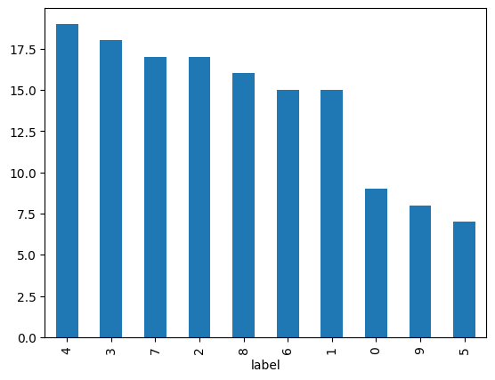

```python
dataset[target_feature].value_counts().plot(kind = 'bar')
plt.show()
```

Display summary statistics for each feature.

```
Summary Stats
```

|  | count | mean | std | min | 25% | 50% | 75% | max |
| --- | --- | --- | --- | --- | --- | --- | --- | --- |
| label | 141.0 | 4.418440 | 2.694322 | 0.0 | 2.0 | 4.0 | 7.0 | 9.0 |
| pixel1 | 141.0 | 0.000000 | 0.000000 | 0.0 | 0.0 | 0.0 | 0.0 | 0.0 |
| pixel2 | 141.0 | 0.000000 | 0.000000 | 0.0 | 0.0 | 0.0 | 0.0 | 0.0 |
| pixel3 | 141.0 | 0.056738 | 0.354019 | 0.0 | 0.0 | 0.0 | 0.0 | 3.0 |
| pixel4 | 141.0 | 0.007092 | 0.084215 | 0.0 | 0.0 | 0.0 | 0.0 | 1.0 |
| ... | ... | ... | ... | ... | ... | ... | ... | ... |
| pixel780 | 141.0 | 26.468085 | 55.909819 | 0.0 | 0.0 | 0.0 | 4.0 | 216.0 |
| pixel781 | 141.0 | 11.382979 | 33.256720 | 0.0 | 0.0 | 0.0 | 0.0 | 221.0 |
| pixel782 | 141.0 | 2.021277 | 11.988368 | 0.0 | 0.0 | 0.0 | 0.0 | 92.0 |
| pixel783 | 141.0 | 0.765957 | 7.229541 | 0.0 | 0.0 | 0.0 | 0.0 | 82.0 |
| pixel784 | 141.0 | 0.049645 | 0.589506 | 0.0 | 0.0 | 0.0 | 0.0 | 7.0 |

785 rows × 8 columns

Distributions

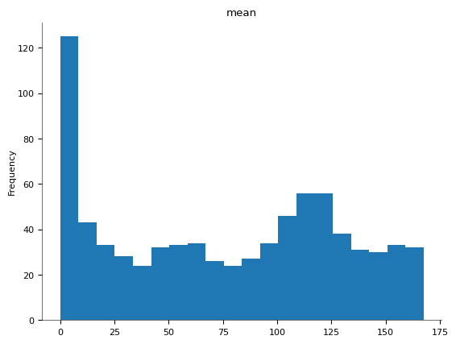

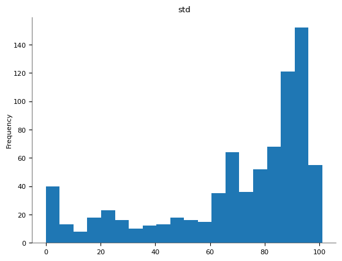

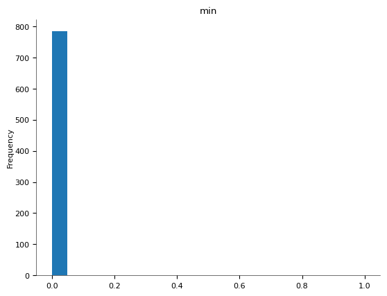

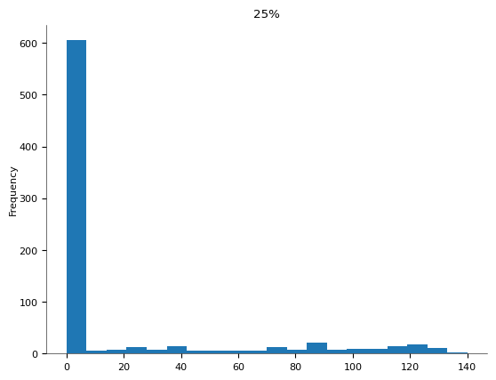

2-d distributions

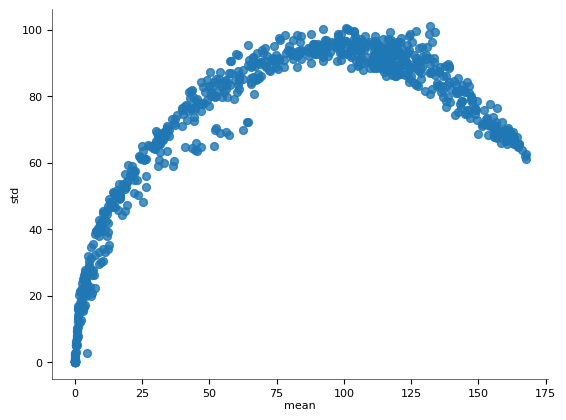

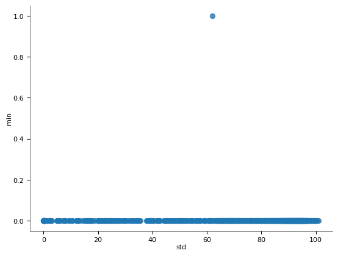

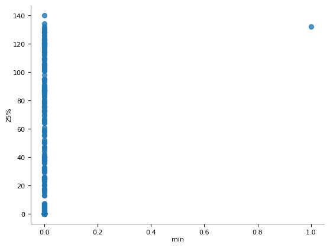

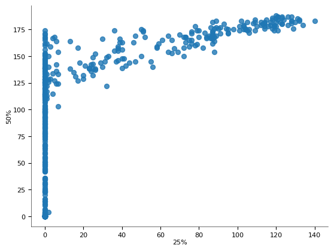

Time series

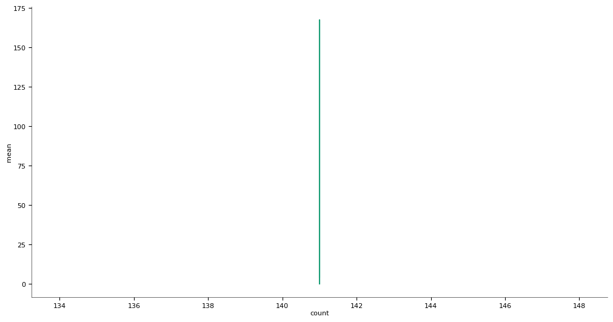

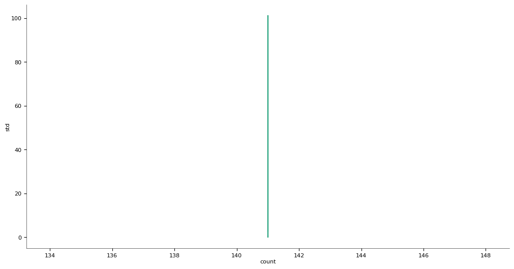

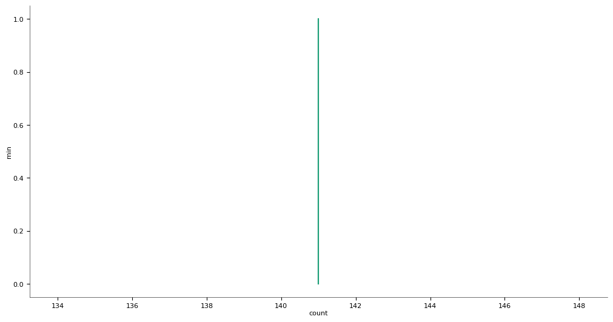

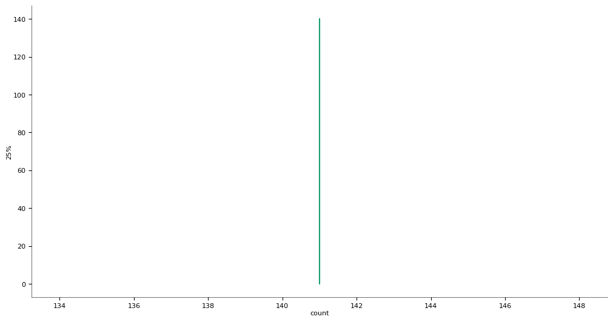

Values

[4 more figures not shown]

```python
# Print descriptive statsitcs for each column
print("Summary Stats")
if dataset.select_dtypes(include=[np.number]).shape[1] > 0:
    display(dataset.select_dtypes(include=[np.number]).describe().transpose())

if dataset.select_dtypes(include=[object]).shape[1] > 0:
    display(dataset.select_dtypes(include=[object]).describe().transpose())
```

Examine presence of missing values

```python
# Check for presence of missing values
print("Missing Values")
print(dataset.isnull().sum().sort_values(ascending = False))
```

```
Missing Values
label       0
pixel516    0
pixel518    0
pixel519    0
pixel520    0
           ..
pixel264    0
pixel265    0
pixel266    0
pixel267    0
pixel784    0
Length: 785, dtype: int64
```

Plot a nice diagram showing missing values - especially usefuol for combined missing values.

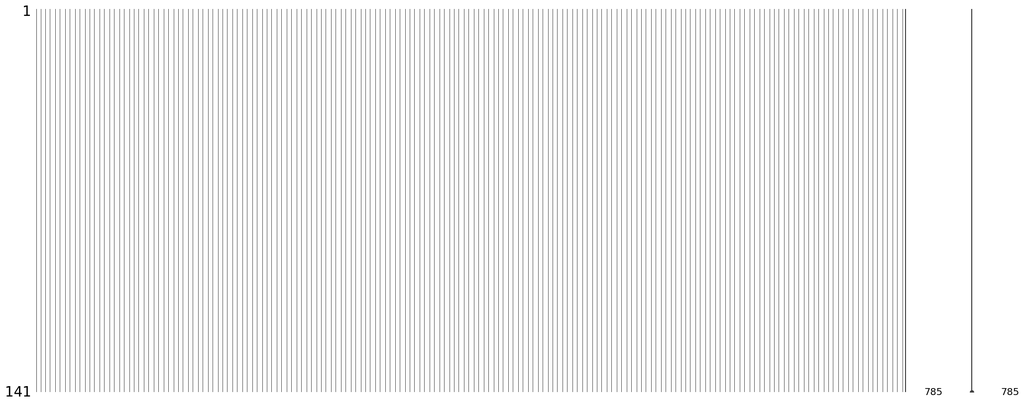

```python
missingno.matrix(dataset)
plt.show()
```

Display some of the instances in the dataset (only really useful for images).

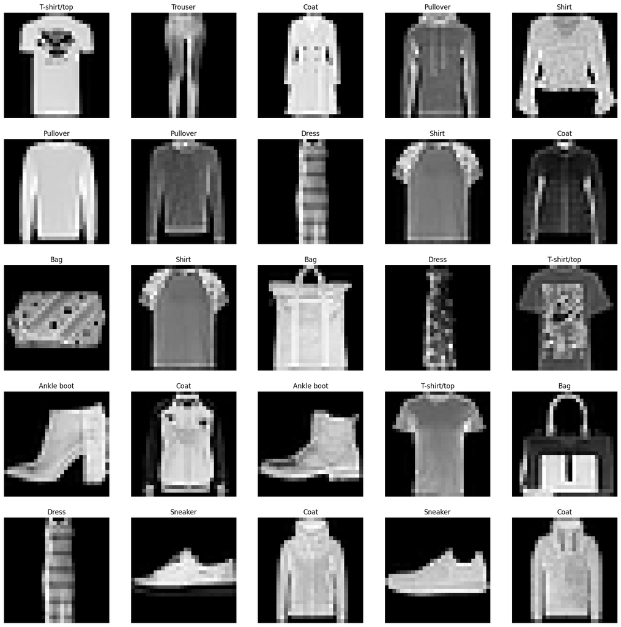

```python
pltsize=4
row_images = 5
col_images = 5
plt.figure(figsize=(col_images*pltsize, row_images*pltsize))

for i in range(row_images * col_images):
    i_rand = random.randint(0, dataset.shape[0] -1 )
    plt.subplot(row_images,col_images,i+1)
    plt.axis('off')
    plt.imshow((dataset.iloc[i_rand, 1:]).values.reshape(28,28), cmap='gray', vmin=0, vmax=256)
    plt.title(str(classes[dataset[target_feature].iloc[i_rand]]))
plt.show()
```

### Partition Dataset

Isolate the descriptive features we are interested in

```python
X = dataset[dataset.columns[1:]]
y = dataset[target_feature] # its "label"
```

Split the data into a **training set** and **validation set** [ 70 : 30 ] split

```python
X_train, X_valid, y_train, y_valid \
    = sklearn.model_selection.train_test_split(X, y,
                        shuffle=True,
                        stratify = y,
                        train_size = 0.7)
```

### Preprocess Dataset

Normalise the data (important for some models but not used in this example.)

```python
# Make the min max scalar object
#min_max_scaler = sklearn.preprocessing.MinMaxScaler((-1,1))
#min_max_scaler.fit(X_train)
#
## Train the scalar on the training dataset
#a = min_max_scaler.transform(X_train)
#
#X_train = pd.DataFrame(a, columns = min_max_scaler.feature_names_in_)
#
## Also normalise other partitions
#a = min_max_scaler.transform(X_valid)
#X_valid = pd.DataFrame(a, columns = min_max_scaler.feature_names_in_)
```

Normalise the data (using hardcoded approach based on domain knowledge)

```python
X_train = (X_train/255*2) - 1
X_valid = (X_valid/255*2) - 1
```

```python
display(X_train.shape)
display(X_train.head())
display(X_valid.shape)
display(X_valid.head())
```

```
(98, 784)
```

|  | pixel1 | pixel2 | pixel3 | pixel4 | pixel5 | pixel6 | pixel7 | pixel8 | pixel9 | pixel10 | ... | pixel775 | pixel776 | pixel777 | pixel778 | pixel779 | pixel780 | pixel781 | pixel782 | pixel783 | pixel784 |
| --- | --- | --- | --- | --- | --- | --- | --- | --- | --- | --- | --- | --- | --- | --- | --- | --- | --- | --- | --- | --- | --- |
| 89 | -1.0 | -1.0 | -1.000000 | -1.0 | -1.0 | -1.000000 | -1.0 | -0.992157 | -0.992157 | -1.0 | ... | -1.000000 | -1.000000 | -1.000000 | -0.121569 | -0.07451 | -0.741176 | -1.0 | -1.0 | -1.0 | -1.0 |
| 511 | -1.0 | -1.0 | -1.000000 | -1.0 | -1.0 | -1.000000 | -1.0 | -0.992157 | -1.000000 | -1.0 | ... | 0.168627 | -0.419608 | -1.000000 | -1.000000 | -1.00000 | -1.000000 | -1.0 | -1.0 | -1.0 | -1.0 |
| 1324 | -1.0 | -1.0 | -1.000000 | -1.0 | -1.0 | -0.984314 | -1.0 | -1.000000 | -1.000000 | -1.0 | ... | 0.458824 | 0.309804 | 0.058824 | 0.050980 | -0.72549 | -1.000000 | -1.0 | -1.0 | -1.0 | -1.0 |
| 912 | -1.0 | -1.0 | -0.976471 | -1.0 | -1.0 | -1.000000 | -1.0 | -1.000000 | -1.000000 | -1.0 | ... | 0.552941 | 0.568627 | 0.450980 | -0.929412 | -1.00000 | -0.992157 | -1.0 | -1.0 | -1.0 | -1.0 |
| 786 | -1.0 | -1.0 | -1.000000 | -1.0 | -1.0 | -1.000000 | -1.0 | -1.000000 | -1.000000 | -1.0 | ... | -1.000000 | -1.000000 | -1.000000 | -1.000000 | -1.00000 | -1.000000 | -1.0 | -1.0 | -1.0 | -1.0 |

5 rows × 784 columns

```
(43, 784)
```

|  | pixel1 | pixel2 | pixel3 | pixel4 | pixel5 | pixel6 | pixel7 | pixel8 | pixel9 | pixel10 | ... | pixel775 | pixel776 | pixel777 | pixel778 | pixel779 | pixel780 | pixel781 | pixel782 | pixel783 | pixel784 |
| --- | --- | --- | --- | --- | --- | --- | --- | --- | --- | --- | --- | --- | --- | --- | --- | --- | --- | --- | --- | --- | --- |
| 947 | -1.0 | -1.0 | -1.0 | -1.0 | -1.0 | -1.000000 | -1.0 | -1.0 | -1.000000 | -1.000000 | ... | -1.000000 | -1.000000 | -1.000000 | -1.0 | -1.000000 | -1.000000 | -1.000000 | -1.000000 | -1.0 | -1.0 |
| 668 | -1.0 | -1.0 | -1.0 | -1.0 | -1.0 | -1.000000 | -1.0 | -1.0 | -1.000000 | -0.003922 | ... | 0.662745 | 0.600000 | -1.000000 | -1.0 | -1.000000 | -1.000000 | -1.000000 | -1.000000 | -1.0 | -1.0 |
| 1006 | -1.0 | -1.0 | -1.0 | -1.0 | -1.0 | -1.000000 | -1.0 | -1.0 | -1.000000 | -0.764706 | ... | -0.443137 | -0.341176 | -0.498039 | -1.0 | 0.145098 | -0.113725 | -0.670588 | -1.000000 | -1.0 | -1.0 |
| 280 | -1.0 | -1.0 | -1.0 | -1.0 | -1.0 | -1.000000 | -1.0 | -1.0 | -1.000000 | -1.000000 | ... | -1.000000 | -1.000000 | -1.000000 | -1.0 | -1.000000 | -1.000000 | -1.000000 | -1.000000 | -1.0 | -1.0 |
| 588 | -1.0 | -1.0 | -1.0 | -1.0 | -1.0 | -0.992157 | -1.0 | -1.0 | -0.984314 | -1.000000 | ... | -1.000000 | -1.000000 | -1.000000 | -1.0 | -1.000000 | -0.027451 | 0.011765 | -0.937255 | -1.0 | -1.0 |

5 rows × 784 columns

Check that we haven't messed up the dataset!

```python
# Print descriptive statsitcs for each column
print("Summary Stats")
if dataset.select_dtypes(include=[np.number]).shape[1] > 0:
    display(X_train.select_dtypes(include=[np.number]).describe().transpose())

if dataset.select_dtypes(include=[object]).shape[1] > 0:
    display(X_train.select_dtypes(include=[object]).describe().transpose())
```

```
Summary Stats
```

|  | count | mean | std | min | 25% | 50% | 75% | max |
| --- | --- | --- | --- | --- | --- | --- | --- | --- |
| pixel1 | 98.0 | -1.000000 | 0.000000 | -1.0 | -1.0 | -1.0 | -1.000000 | -1.000000 |
| pixel2 | 98.0 | -1.000000 | 0.000000 | -1.0 | -1.0 | -1.0 | -1.000000 | -1.000000 |
| pixel3 | 98.0 | -0.999360 | 0.003317 | -1.0 | -1.0 | -1.0 | -1.000000 | -0.976471 |
| pixel4 | 98.0 | -0.999920 | 0.000792 | -1.0 | -1.0 | -1.0 | -1.000000 | -0.992157 |
| pixel5 | 98.0 | -1.000000 | 0.000000 | -1.0 | -1.0 | -1.0 | -1.000000 | -1.000000 |
| ... | ... | ... | ... | ... | ... | ... | ... | ... |
| pixel780 | 98.0 | -0.764226 | 0.463923 | -1.0 | -1.0 | -1.0 | -0.809804 | 0.694118 |
| pixel781 | 98.0 | -0.897879 | 0.287728 | -1.0 | -1.0 | -1.0 | -1.000000 | 0.733333 |
| pixel782 | 98.0 | -0.977831 | 0.112198 | -1.0 | -1.0 | -1.0 | -1.000000 | -0.278431 |
| pixel783 | 98.0 | -0.991357 | 0.067951 | -1.0 | -1.0 | -1.0 | -1.000000 | -0.356863 |
| pixel784 | 98.0 | -0.999440 | 0.005546 | -1.0 | -1.0 | -1.0 | -1.000000 | -0.945098 |

784 rows × 8 columns

image plottign after normalization

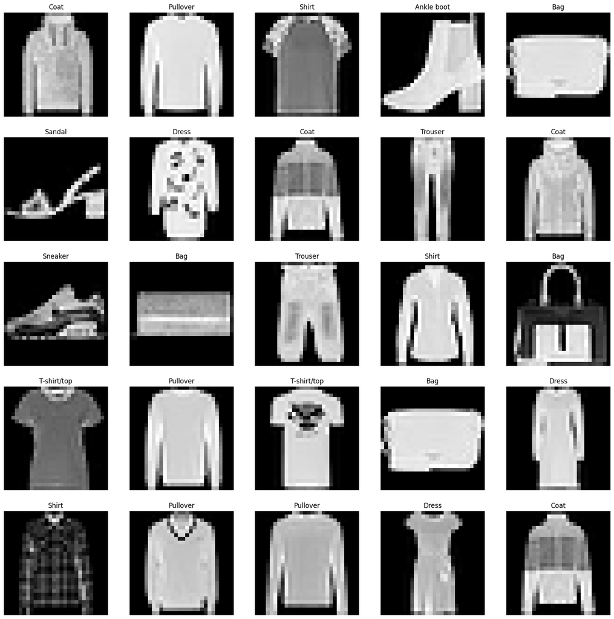

```python
pltsize=4
row_images = 5
col_images = 5
plt.figure(figsize=(col_images*pltsize, row_images*pltsize))

for i in range(row_images * col_images):
    i_rand = random.randint(0, X_train.shape[0] - 1)
    plt.subplot(row_images,col_images,i+1)
    plt.axis('off')
    plt.imshow((X_train.iloc[i_rand]).values.reshape(28,28), cmap='gray', vmin=-1, vmax=1)
   # The second plotting section uses vmin=-1 and vmax=1. This indicates that the pixel values in X_train have been normalized or scaled to a range of -1 to 1.
    plt.title((str(classes[y_train.iloc[i_rand]])))
plt.show()
```

they look the same as before, normalization is therefore effective

## Building Simple Models

```python
my_tree = sklearn.tree.DecisionTreeClassifier(min_samples_split = 0.05)
my_tree = my_tree.fit(X_train,y_train)
```

Assess the performance of the decision tree on the **training set**

```
Accuracy: 0.9387755102040817
              precision    recall  f1-score   support

           0       1.00      1.00      1.00         6
           1       1.00      1.00      1.00        10
           2       0.92      1.00      0.96        12
           3       1.00      1.00      1.00        13
           4       0.75      0.92      0.83        13
           5       1.00      0.80      0.89         5
           6       1.00      0.90      0.95        10
           7       1.00      0.92      0.96        12
           8       1.00      0.91      0.95        11
           9       0.83      0.83      0.83         6

    accuracy                           0.94        98
   macro avg       0.95      0.93      0.94        98
weighted avg       0.95      0.94      0.94        98

Confusion Matrix
```

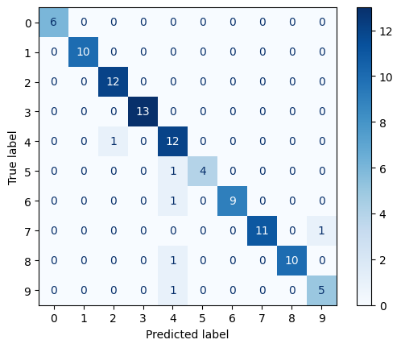

```python
# Make a set of predictions for the training data
y_pred = my_tree.predict(X_train)

# Print performance details
accuracy = sklearn.metrics.accuracy_score(y_train, y_pred) # , normalize=True, sample_weight=None
print("Accuracy: " +  str(accuracy))
print(sklearn.metrics.classification_report(y_train, y_pred))

# Print confusion matrix
print("Confusion Matrix")
sklearn.metrics.ConfusionMatrixDisplay.from_predictions(y_train, y_pred, cmap = 'Blues')
plt.show()
```

Assess the performance of the decision tree on the **validation set**

```
Accuracy: 0.4883720930232558
              precision    recall  f1-score   support

           0       0.75      1.00      0.86         3
           1       1.00      0.80      0.89         5
           2       0.40      0.40      0.40         5
           3       0.67      0.80      0.73         5
           4       0.00      0.00      0.00         6
           5       0.25      0.50      0.33         2
           6       0.67      0.40      0.50         5
           7       0.50      0.40      0.44         5
           8       0.75      0.60      0.67         5
           9       0.00      0.00      0.00         2

    accuracy                           0.49        43
   macro avg       0.50      0.49      0.48        43
weighted avg       0.53      0.49      0.50        43

Confusion Matrix
```

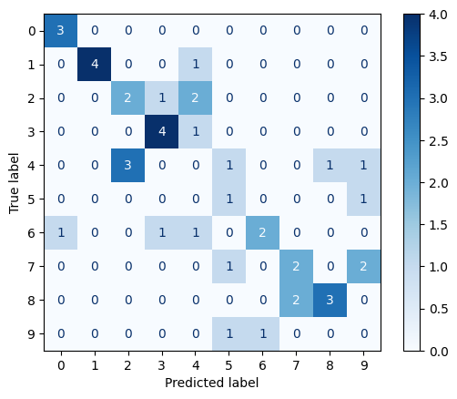

```python
# Make a set of predictions for the test data
y_pred = my_tree.predict(X_valid)

# Print performance details
accuracy = sklearn.metrics.accuracy_score(y_valid, y_pred) # , normalize=True, sample_weight=None
model_valid_accuracy_comparisons["Better Tree"] = accuracy
print("Accuracy: " +  str(accuracy))
print(sklearn.metrics.classification_report(y_valid, y_pred))

# Print confusion matrix
print("Confusion Matrix")
sklearn.metrics.ConfusionMatrixDisplay.from_predictions(y_valid, y_pred, cmap = 'Blues')
plt.show()
```

The validation set avg performance are worse than the training set

## Evaluating Using Cross Validation

Use a cross validation to perfrom an evaluation

```python
my_tree = sklearn.tree.DecisionTreeClassifier(min_samples_split = 0.05)
cv_results = sklearn.model_selection.cross_validate(my_tree, X, y, cv=10)
print(cv_results)
```

```
{'fit_time': array([0.07122374, 0.04113245, 0.04136992, 0.04554749, 0.04071641,
       0.04074407, 0.03916645, 0.04146647, 0.04380536, 0.03941584]), 'score_time': array([0.00620461, 0.00552416, 0.00625253, 0.00740933, 0.00572848,
       0.00607634, 0.00570369, 0.00657535, 0.00589514, 0.00542974]), 'test_score': array([0.46666667, 0.28571429, 0.71428571, 0.64285714, 0.64285714,
       0.71428571, 0.64285714, 0.64285714, 0.5       , 0.42857143])}
```

## Choosing Parameters Using a Grid Search

```python
# Set up the parameter grid to seaerch
param_grid ={'criterion': ['gini', "entropy"], \
             'max_depth': list(range(3, 50, 3)), \
             'min_samples_split': [50]}

# Perform the search
my_tuned_tree = sklearn.model_selection.GridSearchCV(sklearn.tree.DecisionTreeClassifier(), \
                                param_grid, cv=cv_folds, verbose = 2, \
                            return_train_score=True, n_jobs = -1)
my_tuned_tree.fit(X, y)

# Print details
print("Best parameters set found on development set:")
display(my_tuned_tree.best_params_)
model_tuned_params_list["Tuned Tree"] = my_tuned_tree.best_params_
display(my_tuned_tree.best_score_)
display(my_tuned_tree.cv_results_)
```

```
Fitting 2 folds for each of 32 candidates, totalling 64 fits
Best parameters set found on development set:
```

```
{'criterion': 'gini', 'max_depth': 3, 'min_samples_split': 50}
```

```
0.35452716297786724
```

[output not shown]

[output cut: 94 more lines]

```
        0.23943662, 0.23943662]),
 'mean_train_score': array([0.41167002, 0.41167002, 0.41167002, 0.41167002, 0.41167002,
        0.41167002, 0.41167002, 0.41167002, 0.41167002, 0.41167002,
        0.41167002, 0.41167002, 0.41167002, 0.41167002, 0.41167002,
        0.41167002, 0.24828974, 0.24828974, 0.24828974, 0.24828974,
        0.24828974, 0.24828974, 0.24828974, 0.24828974, 0.24828974,
        0.24828974, 0.24828974, 0.24828974, 0.24828974, 0.24828974,
        0.24828974, 0.24828974]),
 'std_train_score': array([0.04547284, 0.04547284, 0.04547284, 0.04547284, 0.04547284,
        0.04547284, 0.04547284, 0.04547284, 0.04547284, 0.04547284,
        0.04547284, 0.04547284, 0.04547284, 0.04547284, 0.04547284,
        0.04547284, 0.00885312, 0.00885312, 0.00885312, 0.00885312,
        0.00885312, 0.00885312, 0.00885312, 0.00885312, 0.00885312,
        0.00885312, 0.00885312, 0.00885312, 0.00885312, 0.00885312,
        0.00885312, 0.00885312])}
```

## Comparing Models

We can easily use the same patterns to train other types of models.

### Random Forests

Train and evaluate a simple model

```python
# Do the same job with random forests
my_model = sklearn.ensemble.RandomForestClassifier(n_estimators=300, \
                                           max_features = 3,\
                                           min_samples_split=200)
my_model.fit(X_train,y_train)
```

```
RandomForestClassifier(max_features=3, min_samples_split=200, n_estimators=300)
```

```
Accuracy: 0.11627906976744186
              precision    recall  f1-score   support

           0       0.00      0.00      0.00         3
           1       0.00      0.00      0.00         5
           2       0.00      0.00      0.00         5
           3       0.12      1.00      0.21         5
           4       0.00      0.00      0.00         6
           5       0.00      0.00      0.00         2
           6       0.00      0.00      0.00         5
           7       0.00      0.00      0.00         5
           8       0.00      0.00      0.00         5
           9       0.00      0.00      0.00         2

    accuracy                           0.12        43
   macro avg       0.01      0.10      0.02        43
weighted avg       0.01      0.12      0.02        43

Confusion Matrix
```

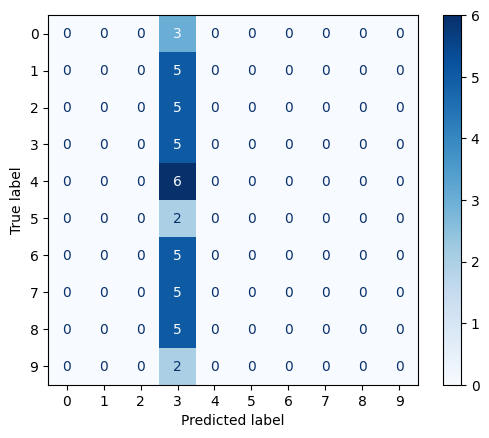

```python
# Make a set of predictions for the test data
y_pred = my_model.predict(X_valid)

# Print performance details
accuracy = sklearn.metrics.accuracy_score(y_valid, y_pred) # , normalize=True, sample_weight=None
model_valid_accuracy_comparisons["Random Forest"] = accuracy
print("Accuracy: " +  str(accuracy))
print(sklearn.metrics.classification_report(y_valid, y_pred))

# Print confusion matrix
print("Confusion Matrix")
sklearn.metrics.ConfusionMatrixDisplay.from_predictions(y_valid, y_pred, cmap = 'Blues')
plt.show()
```

Choose parameters using a grid search

```python
# Set up the parameter grid to seaerch
param_grid = [
 {'n_estimators': list(range(100, 501, 50)), 'max_features': list(range(2, 10, 2)), 'min_samples_split': [200] }
]

# Perform the search
my_tuned_model = sklearn.model_selection.GridSearchCV(sklearn.ensemble.RandomForestClassifier(), param_grid, cv=cv_folds, verbose = 2, n_jobs = -1)
my_tuned_model.fit(X, y)

# Print details
print("Best parameters set found on development set:")
print(my_tuned_model.best_params_)
model_tuned_params_list["Tuned Random Forest"] = my_tuned_model.best_params_
print(my_tuned_model.best_score_)
model_accuracy_comparisons["Tuned Random Forest"] = my_tuned_model.best_score_
```

```
Fitting 2 folds for each of 36 candidates, totalling 72 fits
Best parameters set found on development set:
{'max_features': 2, 'min_samples_split': 200, 'n_estimators': 250}
0.13480885311871227
```

### Bagging

Train and evaluate a simple model

```python
# Do the same job with random forests
my_model = sklearn.ensemble.BaggingClassifier(estimator = sklearn.tree.DecisionTreeClassifier(criterion="entropy", min_samples_leaf = 50), \
                                      n_estimators=10)
my_model.fit(X_train,y_train)
```

```
BaggingClassifier(estimator=DecisionTreeClassifier(criterion='entropy',
                                                   min_samples_leaf=50))
```

```
Accuracy: 0.13953488372093023
              precision    recall  f1-score   support

           0       0.00      0.00      0.00         3
           1       0.00      0.00      0.00         5
           2       0.00      0.00      0.00         5
           3       0.00      0.00      0.00         5
           4       0.14      1.00      0.24         6
           5       0.00      0.00      0.00         2
           6       0.00      0.00      0.00         5
           7       0.00      0.00      0.00         5
           8       0.00      0.00      0.00         5
           9       0.00      0.00      0.00         2

    accuracy                           0.14        43
   macro avg       0.01      0.10      0.02        43
weighted avg       0.02      0.14      0.03        43

Confusion Matrix
```

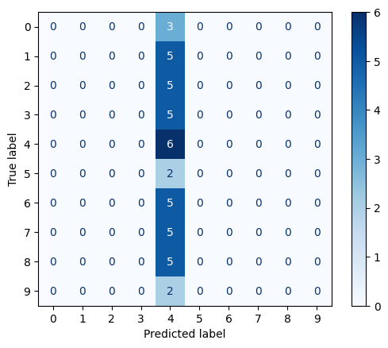

```python
# Make a set of predictions for the validation data
y_pred = my_model.predict(X_valid)

# Print performance details
accuracy = sklearn.metrics.accuracy_score(y_valid, y_pred) # , normalize=True, sample_weight=None
model_valid_accuracy_comparisons["Bagging"] = accuracy
print("Accuracy: " +  str(accuracy))
print(sklearn.metrics.classification_report(y_valid, y_pred))

# Print confusion matrix
print("Confusion Matrix")
sklearn.metrics.ConfusionMatrixDisplay.from_predictions(y_valid, y_pred, cmap = 'Blues')
plt.show()
```

Choose parameters using a grid search

```python
# Set up the parameter grid to seaerch
param_grid = [
 {'n_estimators': list(range(50, 501, 50))}
]

# Perform the search
my_tuned_model = sklearn.model_selection.GridSearchCV(sklearn.ensemble.BaggingClassifier(estimator = sklearn.tree.DecisionTreeClassifier(criterion="entropy", max_depth = 6, min_samples_leaf = 200)), param_grid, cv=cv_folds, verbose = 2, n_jobs = -1)
my_tuned_model.fit(X, y)

# Print details
print("Best parameters set found on development set:")
print(my_tuned_model.best_params_)
model_tuned_params_list["Tuned Bagging"] = my_tuned_model.best_params_
print(my_tuned_model.best_score_)
model_accuracy_comparisons["Tuned Bagging"] = my_tuned_model.best_score_
```

```
Fitting 2 folds for each of 10 candidates, totalling 20 fits
Best parameters set found on development set:
{'n_estimators': 50}
0.13480885311871227
```

### Gradient Boosting

Train and evaluate a simple model

```python
# Do the same job with random forests
my_model = sklearn.ensemble.GradientBoostingClassifier()
my_model.fit(X_train,y_train)
```

```
GradientBoostingClassifier()
```

```
Accuracy: 0.6046511627906976
              precision    recall  f1-score   support

           0       0.00      0.00      0.00         3
           1       1.00      0.80      0.89         5
           2       0.50      0.40      0.44         5
           3       0.50      0.80      0.62         5
           4       0.25      0.33      0.29         6
           5       1.00      0.50      0.67         2
           6       0.33      0.40      0.36         5
           7       1.00      1.00      1.00         5
           8       0.83      1.00      0.91         5
           9       1.00      0.50      0.67         2

    accuracy                           0.60        43
   macro avg       0.64      0.57      0.58        43
weighted avg       0.61      0.60      0.59        43

Confusion Matrix
```

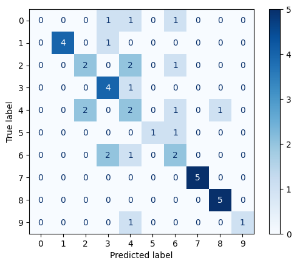

```python
# Make a set of predictions for the validation data
y_pred = my_model.predict(X_valid)

# Print performance details
accuracy = sklearn.metrics.accuracy_score(y_valid, y_pred) # , normalize=True, sample_weight=None
model_valid_accuracy_comparisons["GradBoost"] = accuracy
print("Accuracy: " +  str(accuracy))
print(sklearn.metrics.classification_report(y_valid, y_pred))

# Print confusion matrix
print("Confusion Matrix")
sklearn.metrics.ConfusionMatrixDisplay.from_predictions(y_valid, y_pred, cmap = 'Blues')
plt.show()
```

Choose parameters using a grid search

```python
# Set up the parameter grid to seaerch
param_grid = [
 {'n_estimators': list(range(50, 501, 50)),
 'learning_rate': [0.001, 0.01, 0.1]}
]

# Perform the search
my_tuned_model = sklearn.model_selection.GridSearchCV(sklearn.ensemble.GradientBoostingClassifier(), param_grid, cv=cv_folds, verbose = 2, n_jobs = -1)
my_tuned_model.fit(X, y)

# Print details
print("Best parameters set found on development set:")
print(my_tuned_model.best_params_)
model_tuned_params_list["Tuned GradBoost"] = my_tuned_model.best_params_
print(my_tuned_model.best_score_)
model_accuracy_comparisons["Tuned GradBoost"] = my_tuned_model.best_score_
```

```
Fitting 2 folds for each of 30 candidates, totalling 60 fits
Best parameters set found on development set:
{'learning_rate': 0.1, 'n_estimators': 200}
0.510764587525151
```

### Nearest Neighbour

Train and evaluate a simple model

```python
# Do the same job with random forests
my_model = sklearn.neighbors.KNeighborsClassifier()
my_model = my_model.fit(X_train,y_train)
```

```
Accuracy: 0.7209302325581395
              precision    recall  f1-score   support

           0       0.75      1.00      0.86         3
           1       0.71      1.00      0.83         5
           2       0.67      0.40      0.50         5
           3       0.50      0.60      0.55         5
           4       0.67      0.67      0.67         6
           5       1.00      1.00      1.00         2
           6       0.33      0.20      0.25         5
           7       1.00      0.80      0.89         5
           8       1.00      1.00      1.00         5
           9       0.67      1.00      0.80         2

    accuracy                           0.72        43
   macro avg       0.73      0.77      0.73        43
weighted avg       0.71      0.72      0.70        43

Confusion Matrix
```

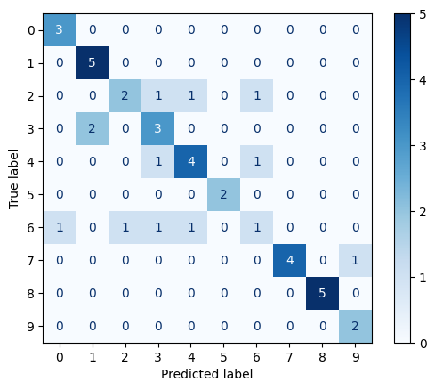

```python
# Make a set of predictions for the test data
y_pred = my_model.predict(X_valid)

# Print performance details
accuracy = sklearn.metrics.accuracy_score(y_valid, y_pred) # , normalize=True, sample_weight=None
model_valid_accuracy_comparisons["kNN"] = accuracy
print("Accuracy: " +  str(accuracy))
print(sklearn.metrics.classification_report(y_valid, y_pred))

# Print confusion matrix
print("Confusion Matrix")
sklearn.metrics.ConfusionMatrixDisplay.from_predictions(y_valid, y_pred, cmap = 'Blues')
plt.show()
```

Choose parameters using a grid search

```python
# Set up the parameter grid to seaerch
param_grid = [
               {'n_neighbors': list(range(1, 50, 5))}
]

# Perform the search
my_tuned_model = sklearn.model_selection.GridSearchCV(sklearn.neighbors.KNeighborsClassifier(), param_grid,
                                                      cv=cv_folds, verbose = 2,
                                                      n_jobs = -1)
my_tuned_model.fit(X, y)

# Print details
print("Best parameters set found on development set:")
print(my_tuned_model.best_params_)
model_tuned_params_list["Tuned kNN"] = my_tuned_model.best_params_
print(my_tuned_model.best_score_)
model_accuracy_comparisons["Tuned kNN"] = my_tuned_model.best_score_
```

```
Fitting 2 folds for each of 10 candidates, totalling 20 fits
Best parameters set found on development set:
{'n_neighbors': 1}
0.6595573440643863
```

### Compare Results

```python
display(model_valid_accuracy_comparisons)
```

```
{'Better Tree': 0.4883720930232558,
 'Random Forest': 0.11627906976744186,
 'Bagging': 0.13953488372093023,
 'GradBoost': 0.6046511627906976,
 'kNN': 0.7209302325581395}
```

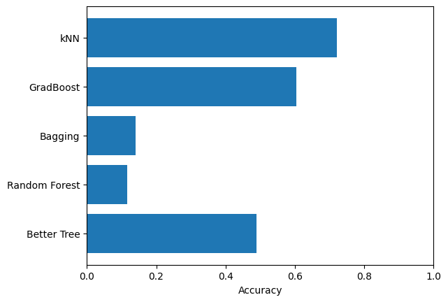

```python
plt.xlim(0, 1.0)
_ = plt.barh(range(len(model_valid_accuracy_comparisons)), list(model_valid_accuracy_comparisons.values()), align='center')
_= plt.yticks(range(len(model_valid_accuracy_comparisons)), list(model_valid_accuracy_comparisons.keys()))
plt.xlabel("Accuracy")
plt.show()
```

```python
display(model_accuracy_comparisons)
```

```
{'Tuned Random Forest': 0.13480885311871227,
 'Tuned Bagging': 0.13480885311871227,
 'Tuned GradBoost': 0.510764587525151,
 'Tuned kNN': 0.6595573440643863}
```

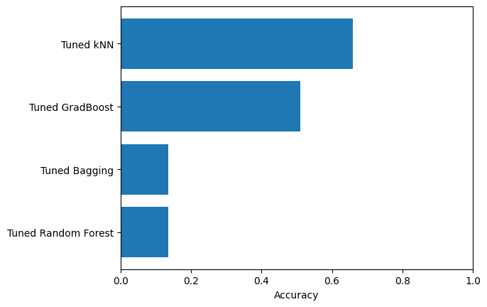

```python
plt.xlim(0, 1.0)
plt.barh(range(len(model_accuracy_comparisons)), list(model_accuracy_comparisons.values()), align='center')
plt.yticks(range(len(model_accuracy_comparisons)), list(model_accuracy_comparisons.keys()))
plt.xlabel("Accuracy")
plt.show()
```

```python
display(model_tuned_params_list)
```

```
{'Tuned Tree': {'criterion': 'gini', 'max_depth': 3, 'min_samples_split': 50},
 'Tuned Random Forest': {'max_features': 2,
  'min_samples_split': 200,
  'n_estimators': 250},
 'Tuned Bagging': {'n_estimators': 50},
 'Tuned GradBoost': {'learning_rate': 0.1, 'n_estimators': 200},
 'Tuned kNN': {'n_neighbors': 1}}
```

## Test Best Model On Test Dataset

```python
test_filename = 'fashion-mnist_test.csv'
test_dataset = pd.read_csv(test_filename)
test_dataset.head()
```

|  | label | pixel1 | pixel2 | pixel3 | pixel4 | pixel5 | pixel6 | pixel7 | pixel8 | pixel9 | ... | pixel775 | pixel776 | pixel777 | pixel778 | pixel779 | pixel780 | pixel781 | pixel782 | pixel783 | pixel784 |
| --- | --- | --- | --- | --- | --- | --- | --- | --- | --- | --- | --- | --- | --- | --- | --- | --- | --- | --- | --- | --- | --- |
| 0 | 0 | 0 | 0 | 0 | 0 | 0 | 0 | 0 | 9 | 8 | ... | 103.0 | 87.0 | 56.0 | 0.0 | 0.0 | 0.0 | 0.0 | 0.0 | 0.0 | 0.0 |
| 1 | 1 | 0 | 0 | 0 | 0 | 0 | 0 | 0 | 0 | 0 | ... | 34.0 | 0.0 | 0.0 | 0.0 | 0.0 | 0.0 | 0.0 | 0.0 | 0.0 | 0.0 |
| 2 | 2 | 0 | 0 | 0 | 0 | 0 | 0 | 14 | 53 | 99 | ... | 0.0 | 0.0 | 0.0 | 0.0 | 63.0 | 53.0 | 31.0 | 0.0 | 0.0 | 0.0 |
| 3 | 2 | 0 | 0 | 0 | 0 | 0 | 0 | 0 | 0 | 0 | ... | 137.0 | 126.0 | 140.0 | 0.0 | 133.0 | 224.0 | 222.0 | 56.0 | 0.0 | 0.0 |
| 4 | 3 | 0 | 0 | 0 | 0 | 0 | 0 | 0 | 0 | 0 | ... | 0.0 | 0.0 | 0.0 | 0.0 | 0.0 | 0.0 | 0.0 | 0.0 | 0.0 | 0.0 |

5 rows × 785 columns

```python
X_test = test_dataset[test_dataset.columns[1:]]
y_test = np.array(test_dataset[target_feature])
```

```python
X_test = (X_test/255*2) - 1
```

```python
display(X_test.shape)
display(X_test.head())
print(X_test.isnull().sum().sort_values(ascending=False))
```

```
(943, 784)
```

|  | pixel1 | pixel2 | pixel3 | pixel4 | pixel5 | pixel6 | pixel7 | pixel8 | pixel9 | pixel10 | ... | pixel775 | pixel776 | pixel777 | pixel778 | pixel779 | pixel780 | pixel781 | pixel782 | pixel783 | pixel784 |
| --- | --- | --- | --- | --- | --- | --- | --- | --- | --- | --- | --- | --- | --- | --- | --- | --- | --- | --- | --- | --- | --- |
| 0 | -1.0 | -1.0 | -1.0 | -1.0 | -1.0 | -1.0 | -1.000000 | -0.929412 | -0.937255 | -1.000000 | ... | -0.192157 | -0.317647 | -0.560784 | -1.0 | -1.000000 | -1.000000 | -1.000000 | -1.000000 | -1.0 | -1.0 |
| 1 | -1.0 | -1.0 | -1.0 | -1.0 | -1.0 | -1.0 | -1.000000 | -1.000000 | -1.000000 | -1.000000 | ... | -0.733333 | -1.000000 | -1.000000 | -1.0 | -1.000000 | -1.000000 | -1.000000 | -1.000000 | -1.0 | -1.0 |
| 2 | -1.0 | -1.0 | -1.0 | -1.0 | -1.0 | -1.0 | -0.890196 | -0.584314 | -0.223529 | -0.866667 | ... | -1.000000 | -1.000000 | -1.000000 | -1.0 | -0.505882 | -0.584314 | -0.756863 | -1.000000 | -1.0 | -1.0 |
| 3 | -1.0 | -1.0 | -1.0 | -1.0 | -1.0 | -1.0 | -1.000000 | -1.000000 | -1.000000 | 0.262745 | ... | 0.074510 | -0.011765 | 0.098039 | -1.0 | 0.043137 | 0.756863 | 0.741176 | -0.560784 | -1.0 | -1.0 |
| 4 | -1.0 | -1.0 | -1.0 | -1.0 | -1.0 | -1.0 | -1.000000 | -1.000000 | -1.000000 | -1.000000 | ... | -1.000000 | -1.000000 | -1.000000 | -1.0 | -1.000000 | -1.000000 | -1.000000 | -1.000000 | -1.0 | -1.0 |

5 rows × 784 columns

```
pixel393    1
pixel540    1
pixel518    1
pixel519    1
pixel520    1
           ..
pixel214    0
pixel215    0
pixel216    0
pixel217    0
pixel1      0
Length: 784, dtype: int64
```

Let's remove Nan Values in test dataset

```python
imputer = sklearn.impute.SimpleImputer(strategy='mean')  # Replace with 'median' or other strategies if needed
X_test = imputer.fit_transform(X_test)
```

we will be using Tuned kNN because it got the best performances

```python
my_model = sklearn.neighbors.KNeighborsClassifier(**(model_tuned_params_list["Tuned kNN"]))
my_model = my_model.fit(X_train,y_train)
```

```
Accuracy: 0.6595970307529162
              precision    recall  f1-score   support

           0       0.75      0.46      0.57        89
           1       0.86      0.94      0.90        86
           2       0.50      0.52      0.51       103
           3       0.68      0.78      0.72        96
           4       0.44      0.51      0.47        91
           5       0.91      0.45      0.60        92
           6       0.29      0.34      0.32        94
           7       0.65      0.93      0.76        98
           8       0.92      0.77      0.84        95
           9       0.91      0.89      0.90        99

    accuracy                           0.66       943
   macro avg       0.69      0.66      0.66       943
weighted avg       0.69      0.66      0.66       943

Confusion Matrix
```

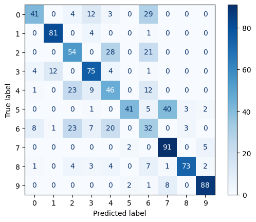

```python
# Make a set of predictions for the test data
y_pred = my_model.predict(X_test)

# Print performance details
accuracy = sklearn.metrics.accuracy_score(y_test, y_pred) # , normalize=True, sample_weight=None
print("Accuracy: " +  str(accuracy))
print(sklearn.metrics.classification_report(y_test, y_pred))

# Print confusion matrix
print("Confusion Matrix")
sklearn.metrics.ConfusionMatrixDisplay.from_predictions(y_test, y_pred, cmap = 'Blues')
plt.show()
```

Using Tuned kNN with {'n_neighbors': 1}} is the most optimal model we have found using gridsearch for the fashion-mninst dataset with an accurary around 0.66